# Fitness Tracker Data Analysis

Nadim

2024-12-11

## Introduction

As a part of the Google Data Analytics Certification, I am analyzing user data collected from their personal fitness devices, to gain insights into usage habit. This analysis aims to provide actionable recommendations to guide [Bellabeat’s](https://bellabeat.com/) marketing strategy. Bellabeat is a high-tech manufacturer of health-focused smart products.

I will follow the six-step data analysis process: ask, prepare, process, analyze, share and act as introduced in the certification course. This document demonstrates key skills acquired through the program and present use cases relevant to stakeholder’s at Bellabeat.

## 1. Ask

*Deliverable: A summary of the business task and key stakeholders.*

**Business Task:** The task at hand is to analyze the Fitbit Fitness Tracker Data to identify trends in smart device usage and apply these insights to enhance Bellabeat’s marketing strategy. The key questions addressed in this analysis are:

- What are some trends in smart device usage?
- How could these trends apply to Bellabeat customers?
- How could these trends help influence Bellabeat marketing strategy?

**Key Stakeholders:**

- Urška Sršen: Bellabeat’s cofounder and Chief Creative Officer
- Sando Mur: Mathematician and Bellabeat’s cofounder;
- Bellabeat marketing analytics team

## 2. Prepare

*Deliverable: A description of all data sources used.*

**Data Source**

**[Fitbit Fitness Tracker Data](https://www.kaggle.com/datasets/arashnic/fitbit/data) (CC0: Public Domain, dataset made available through [Mobius](https://www.kaggle.com/arashnic))**

**Inital Setup**

To prepare the environment for analysis, I will load the following R packages: *`tidyverse`: For data manipulation and visualization.* `skimr`: To provide a quick summary of the data. *`janitor`:For data cleaning and ensuring consistency in column names.

```r
library(dplyr)
library(tidyverse)
library(skimr)
library(janitor)
library(scales)
```

```r
library(corrplot)
options(scipen = 999)
```

**Data Description**

The files contain daily, hourly, and minute-level outputs on various measures, including:

*Steps* Calories burned *Intensities* Heart rate *Sleep monitoring

Since the goal is to identify high-level trends in usage, the focus will primarily be on daily and hourly datasets, as they provide sufficient granularity for this purpose.

**Importing the Datasets**

Let’s start by importing the csv files into dataframes for exploration.

```r
# Importing 03/12/2016-04/11/16 datasets

daily_activity_03_12 <- read_csv("~/Desktop/PROJECTS/bellabeat-case-study/data/Fitabase Data 3.12.16-4.11.16/dailyActivity_merged.csv")
# Daily aggregated data for intensities, calories, steps and sleep is present between 03/12/2016-04/11/2016, so I will use the hourly and minute level outputs to compute daily totals.

hourly_calories_03_12 <- read_csv("~/Desktop/PROJECTS/bellabeat-case-study/data/Fitabase Data 3.12.16-4.11.16/hourlyCalories_merged.csv")
hourly_steps_03_12 <- read_csv("~/Desktop/PROJECTS/bellabeat-case-study/data/Fitabase Data 3.12.16-4.11.16/hourlySteps_merged.csv")
minute_sleep_03_12 <- read_csv("~/Desktop/PROJECTS/bellabeat-case-study/data/Fitabase Data 3.12.16-4.11.16/minuteSleep_merged.csv")
weight_log_03_12 <- read_csv("~/Desktop/PROJECTS/bellabeat-case-study/data/Fitabase Data 3.12.16-4.11.16/weightLogInfo_merged.csv")
# Importing 04/12/16-05/12/2016 datasets

daily_activity_04_12 <- read_csv("~/Desktop/PROJECTS/bellabeat-case-study/data/Fitabase Data 4.12.16-5.12.16/dailyActivity_merged.csv")
hourly_calories_04_12 <- read_csv("~/Desktop/PROJECTS/bellabeat-case-study/data/Fitabase Data 4.12.16-5.12.16/hourlyCalories_merged.csv")
hourly_steps_04_12 <- read_csv("~/Desktop/PROJECTS/bellabeat-case-study/data/Fitabase Data 4.12.16-5.12.16/hourlySteps_merged.csv")
minute_sleep_04_12 <- read_csv("~/Desktop/PROJECTS/bellabeat-case-study/data/Fitabase Data 4.12.16-5.12.16/minuteSleep_merged.csv")
weight_log_04_12 <- read_csv("~/Desktop/PROJECTS/bellabeat-case-study/data/Fitabase Data 4.12.16-5.12.16/weightLogInfo_merged.csv")
```

Let’s explore and compare the datasets to see how its organized.

```r
head(daily_activity_03_12)
```

```
## # A tibble: 6 × 15
##           Id ActivityDate TotalSteps TotalDistance TrackerDistance
##        <dbl> <chr>             <dbl>         <dbl>           <dbl>
## 1 1503960366 3/25/2016         11004          7.11            7.11
## 2 1503960366 3/26/2016         17609         11.6            11.6
## 3 1503960366 3/27/2016         12736          8.53            8.53
## 4 1503960366 3/28/2016         13231          8.93            8.93
## 5 1503960366 3/29/2016         12041          7.85            7.85
## 6 1503960366 3/30/2016         10970          7.16            7.16
## # ℹ 10 more variables: LoggedActivitiesDistance <dbl>,
## #   VeryActiveDistance <dbl>, ModeratelyActiveDistance <dbl>,
## #   LightActiveDistance <dbl>, SedentaryActiveDistance <dbl>,
## #   VeryActiveMinutes <dbl>, FairlyActiveMinutes <dbl>,
## #   LightlyActiveMinutes <dbl>, SedentaryMinutes <dbl>, Calories <dbl>
```

```r
head(daily_activity_04_12)
```

```
## # A tibble: 6 × 15
##           Id ActivityDate TotalSteps TotalDistance TrackerDistance
##        <dbl> <chr>             <dbl>         <dbl>           <dbl>
## 1 1503960366 4/12/2016         13162          8.5             8.5
## 2 1503960366 4/13/2016         10735          6.97            6.97
## 3 1503960366 4/14/2016         10460          6.74            6.74
## 4 1503960366 4/15/2016          9762          6.28            6.28
## 5 1503960366 4/16/2016         12669          8.16            8.16
## 6 1503960366 4/17/2016          9705          6.48            6.48
## # ℹ 10 more variables: LoggedActivitiesDistance <dbl>,
## #   VeryActiveDistance <dbl>, ModeratelyActiveDistance <dbl>,
## #   LightActiveDistance <dbl>, SedentaryActiveDistance <dbl>,
## #   VeryActiveMinutes <dbl>, FairlyActiveMinutes <dbl>,
## #   LightlyActiveMinutes <dbl>, SedentaryMinutes <dbl>, Calories <dbl>
```

```r
head(hourly_calories_03_12)
```

```
## # A tibble: 6 × 3
##           Id ActivityHour          Calories
##        <dbl> <chr>                    <dbl>
## 1 1503960366 3/12/2016 12:00:00 AM       48
## 2 1503960366 3/12/2016 1:00:00 AM        48
## 3 1503960366 3/12/2016 2:00:00 AM        48
## 4 1503960366 3/12/2016 3:00:00 AM        48
## 5 1503960366 3/12/2016 4:00:00 AM        48
## 6 1503960366 3/12/2016 5:00:00 AM        48
```

```r
head(hourly_calories_04_12)
```

```
## # A tibble: 6 × 3
##           Id ActivityHour          Calories
##        <dbl> <chr>                    <dbl>
## 1 1503960366 4/12/2016 12:00:00 AM       81
## 2 1503960366 4/12/2016 1:00:00 AM        61
## 3 1503960366 4/12/2016 2:00:00 AM        59
## 4 1503960366 4/12/2016 3:00:00 AM        47
## 5 1503960366 4/12/2016 4:00:00 AM        48
## 6 1503960366 4/12/2016 5:00:00 AM        48
```

```r
head(minute_sleep_03_12)
```

```
## # A tibble: 6 × 4
##           Id date                 value       logId
##        <dbl> <chr>                <dbl>       <dbl>
## 1 1503960366 3/13/2016 2:39:30 AM     1 11114919637
## 2 1503960366 3/13/2016 2:40:30 AM     1 11114919637
## 3 1503960366 3/13/2016 2:41:30 AM     1 11114919637
## 4 1503960366 3/13/2016 2:42:30 AM     1 11114919637
## 5 1503960366 3/13/2016 2:43:30 AM     1 11114919637
## 6 1503960366 3/13/2016 2:44:30 AM     1 11114919637
```

```r
head(minute_sleep_04_12)
```

```
## # A tibble: 6 × 4
##           Id date                 value       logId
##        <dbl> <chr>                <dbl>       <dbl>
## 1 1503960366 4/12/2016 2:47:30 AM     3 11380564589
## 2 1503960366 4/12/2016 2:48:30 AM     2 11380564589
## 3 1503960366 4/12/2016 2:49:30 AM     1 11380564589
## 4 1503960366 4/12/2016 2:50:30 AM     1 11380564589
## 5 1503960366 4/12/2016 2:51:30 AM     1 11380564589
## 6 1503960366 4/12/2016 2:52:30 AM     1 11380564589
```

```r
head(hourly_steps_03_12)
```

```
## # A tibble: 6 × 3
##           Id ActivityHour          StepTotal
##        <dbl> <chr>                     <dbl>
## 1 1503960366 3/12/2016 12:00:00 AM         0
## 2 1503960366 3/12/2016 1:00:00 AM          0
## 3 1503960366 3/12/2016 2:00:00 AM          0
## 4 1503960366 3/12/2016 3:00:00 AM          0
## 5 1503960366 3/12/2016 4:00:00 AM          0
## 6 1503960366 3/12/2016 5:00:00 AM          0
```

```r
head(hourly_steps_04_12)
```

```
## # A tibble: 6 × 3
##           Id ActivityHour          StepTotal
##        <dbl> <chr>                     <dbl>
## 1 1503960366 4/12/2016 12:00:00 AM       373
## 2 1503960366 4/12/2016 1:00:00 AM        160
## 3 1503960366 4/12/2016 2:00:00 AM        151
## 4 1503960366 4/12/2016 3:00:00 AM          0
## 5 1503960366 4/12/2016 4:00:00 AM          0
## 6 1503960366 4/12/2016 5:00:00 AM          0
```

```r
head(weight_log_03_12)
```

```
## # A tibble: 6 × 8
##           Id Date       WeightKg WeightPounds   Fat   BMI IsManualReport   LogId
##        <dbl> <chr>         <dbl>        <dbl> <dbl> <dbl> <lgl>            <dbl>
## 1 1503960366 4/5/2016 …     53.3         118.    22  23.0 TRUE           1.46e12
## 2 1927972279 4/10/2016…    130.          286.    NA  46.2 FALSE          1.46e12
## 3 2347167796 4/3/2016 …     63.4         140.    10  24.8 TRUE           1.46e12
## 4 2873212765 4/6/2016 …     56.7         125.    NA  21.5 TRUE           1.46e12
## 5 2873212765 4/7/2016 …     57.2         126.    NA  21.6 TRUE           1.46e12
## 6 2891001357 4/5/2016 …     88.4         195.    NA  25.0 TRUE           1.46e12
```

```r
head(weight_log_04_12)
```

```
## # A tibble: 6 × 8
##           Id Date       WeightKg WeightPounds   Fat   BMI IsManualReport   LogId
##        <dbl> <chr>         <dbl>        <dbl> <dbl> <dbl> <lgl>            <dbl>
## 1 1503960366 5/2/2016 …     52.6         116.    22  22.6 TRUE           1.46e12
## 2 1503960366 5/3/2016 …     52.6         116.    NA  22.6 TRUE           1.46e12
## 3 1927972279 4/13/2016…    134.          294.    NA  47.5 FALSE          1.46e12
## 4 2873212765 4/21/2016…     56.7         125.    NA  21.5 TRUE           1.46e12
## 5 2873212765 5/12/2016…     57.3         126.    NA  21.7 TRUE           1.46e12
## 6 4319703577 4/17/2016…     72.4         160.    25  27.5 TRUE           1.46e12
```

**Key Observations**

Primary Key: The Id column is common across all dataframes, making it suitable as a primary key for merging or combining datasets when needed.

Date Formatting: The date columns are not in the correct data type, these need to be converted to Date or DateTime formats.

Time Granularity: The data is recorded at various time intervals: minute, hour, and day. To ensure consistency in analysis, the datasets need to be transformed into a uniform time granularity, such as daily summaries.

**Data Credibility**

Outdated Data: The data was collected in 2016 over a span of two months, limiting its relevance to current trends.

Lack of Demographic Information: The absence of demographic details prevents the assessment of sampling bias, further reducing the dataset’s reliability.

## 3. Process

*Deliverable: Documentation of any cleaning or manipulation of data*

**Date Formatting: Converting the datatype of date columns into datetime datatype**

Let’s start by converting the data formatting for the datasets and since we are never going to perform arithmetic operations on participant ID number, lets covert the column to string.

```r
daily_activity_03_12 <- daily_activity_03_12 %>%
  mutate(ActivityDate = mdy(ActivityDate),
         Id = as.character(Id))

daily_activity_04_12 <- daily_activity_04_12 %>%
  mutate(ActivityDate = mdy(ActivityDate),
         Id = as.character(Id))

hourly_calories_03_12 <- hourly_calories_03_12 %>%
  mutate(ActivityHour = mdy_hms(ActivityHour),
         Id = as.character(Id))

hourly_calories_04_12 <- hourly_calories_04_12 %>%
  mutate(ActivityHour = mdy_hms(ActivityHour),
         Id = as.character(Id))

hourly_steps_03_12 <- hourly_steps_03_12 %>%
  mutate(ActivityHour = mdy_hms(ActivityHour),
         Id = as.character(Id))

hourly_steps_04_12 <- hourly_steps_04_12 %>%
  mutate(ActivityHour = mdy_hms(ActivityHour),
         Id = as.character(Id))

minute_sleep_03_12 <- minute_sleep_03_12 %>%
  mutate(date = mdy_hms(date),
         Id = as.character(Id))

minute_sleep_04_12 <- minute_sleep_04_12 %>%
  mutate(date = mdy_hms(date),
         Id = as.character(Id))

weight_log_03_12 <- weight_log_03_12 %>%
  mutate(Date = mdy_hms(Date),
         Id = as.character(Id))

weight_log_04_12 <- weight_log_04_12 %>%
  mutate(Date = mdy_hms(Date),
         Id = as.character(Id))
```

**Data Cleaning: Removing duplicates and identifying outliers/missing data**

Before diving into analysis, it’s crucial to clean the data by handling duplicates, missing values, and outliers. We’ll start by looking at quick summary statistics to identify these issues.

```r
# No. of unique participants in each datasets

n_distinct(daily_activity_03_12$Id)
```

```
## [1] 35
```

```r
n_distinct(daily_activity_04_12$Id)
```

```
## [1] 33
```

```r
n_distinct(hourly_calories_03_12$Id)
```

```
## [1] 34
```

```r
n_distinct(hourly_calories_04_12$Id)
```

```
## [1] 33
```

```r
n_distinct(hourly_steps_03_12$Id)
```

```
## [1] 34
```

```r
n_distinct(hourly_steps_04_12$Id)
```

```
## [1] 33
```

```r
n_distinct(minute_sleep_03_12$Id)
```

```
## [1] 23
```

```r
n_distinct(minute_sleep_04_12$Id)
```

```
## [1] 24
```

```r
n_distinct(weight_log_03_12$Id)
```

```
## [1] 11
```

```r
n_distinct(weight_log_04_12$Id)
```

```
## [1] 8
```

```r
# Summary stats for each datasets

summary(daily_activity_03_12)
```

```
##       Id             ActivityDate          TotalSteps    TotalDistance
##  Length:457         Min.   :2016-03-12   Min.   :    0   Min.   : 0.000
##  Class :character   1st Qu.:2016-04-02   1st Qu.: 1988   1st Qu.: 1.410
##  Mode  :character   Median :2016-04-05   Median : 5986   Median : 4.090
##                     Mean   :2016-04-04   Mean   : 6547   Mean   : 4.664
##                     3rd Qu.:2016-04-08   3rd Qu.:10198   3rd Qu.: 7.160
##                     Max.   :2016-04-12   Max.   :28497   Max.   :27.530
##  TrackerDistance LoggedActivitiesDistance VeryActiveDistance
##  Min.   : 0.00   Min.   :0.0000           Min.   : 0.000
##  1st Qu.: 1.28   1st Qu.:0.0000           1st Qu.: 0.000
##  Median : 4.09   Median :0.0000           Median : 0.000
##  Mean   : 4.61   Mean   :0.1794           Mean   : 1.181
##  3rd Qu.: 7.11   3rd Qu.:0.0000           3rd Qu.: 1.310
##  Max.   :27.53   Max.   :6.7271           Max.   :21.920
##  ModeratelyActiveDistance LightActiveDistance SedentaryActiveDistance
##  Min.   :0.0000           Min.   : 0.00       Min.   :0.000000
##  1st Qu.:0.0000           1st Qu.: 0.87       1st Qu.:0.000000
##  Median :0.0200           Median : 2.93       Median :0.000000
##  Mean   :0.4786           Mean   : 2.89       Mean   :0.001904
##  3rd Qu.:0.6700           3rd Qu.: 4.46       3rd Qu.:0.000000
##  Max.   :6.4000           Max.   :12.51       Max.   :0.100000
##  VeryActiveMinutes FairlyActiveMinutes LightlyActiveMinutes SedentaryMinutes
##  Min.   :  0.00    Min.   :  0.00      Min.   :  0.0        Min.   :  32.0
##  1st Qu.:  0.00    1st Qu.:  0.00      1st Qu.: 64.0        1st Qu.: 728.0
##  Median :  0.00    Median :  1.00      Median :181.0        Median :1057.0
##  Mean   : 16.62    Mean   : 13.07      Mean   :170.1        Mean   : 995.3
##  3rd Qu.: 25.00    3rd Qu.: 16.00      3rd Qu.:257.0        3rd Qu.:1285.0
##  Max.   :202.00    Max.   :660.00      Max.   :720.0        Max.   :1440.0
##     Calories
##  Min.   :   0
##  1st Qu.:1776
##  Median :2062
##  Mean   :2189
##  3rd Qu.:2667
##  Max.   :4562
```

```r
summary(daily_activity_04_12)
```

```
##       Id             ActivityDate          TotalSteps    TotalDistance
##  Length:940         Min.   :2016-04-12   Min.   :    0   Min.   : 0.000
##  Class :character   1st Qu.:2016-04-19   1st Qu.: 3790   1st Qu.: 2.620
##  Mode  :character   Median :2016-04-26   Median : 7406   Median : 5.245
##                     Mean   :2016-04-26   Mean   : 7638   Mean   : 5.490
##                     3rd Qu.:2016-05-04   3rd Qu.:10727   3rd Qu.: 7.713
##                     Max.   :2016-05-12   Max.   :36019   Max.   :28.030
##  TrackerDistance  LoggedActivitiesDistance VeryActiveDistance
##  Min.   : 0.000   Min.   :0.0000           Min.   : 0.000
##  1st Qu.: 2.620   1st Qu.:0.0000           1st Qu.: 0.000
##  Median : 5.245   Median :0.0000           Median : 0.210
##  Mean   : 5.475   Mean   :0.1082           Mean   : 1.503
##  3rd Qu.: 7.710   3rd Qu.:0.0000           3rd Qu.: 2.053
##  Max.   :28.030   Max.   :4.9421           Max.   :21.920
##  ModeratelyActiveDistance LightActiveDistance SedentaryActiveDistance
##  Min.   :0.0000           Min.   : 0.000      Min.   :0.000000
##  1st Qu.:0.0000           1st Qu.: 1.945      1st Qu.:0.000000
##  Median :0.2400           Median : 3.365      Median :0.000000
##  Mean   :0.5675           Mean   : 3.341      Mean   :0.001606
##  3rd Qu.:0.8000           3rd Qu.: 4.782      3rd Qu.:0.000000
##  Max.   :6.4800           Max.   :10.710      Max.   :0.110000
##  VeryActiveMinutes FairlyActiveMinutes LightlyActiveMinutes SedentaryMinutes
##  Min.   :  0.00    Min.   :  0.00      Min.   :  0.0        Min.   :   0.0
##  1st Qu.:  0.00    1st Qu.:  0.00      1st Qu.:127.0        1st Qu.: 729.8
##  Median :  4.00    Median :  6.00      Median :199.0        Median :1057.5
##  Mean   : 21.16    Mean   : 13.56      Mean   :192.8        Mean   : 991.2
##  3rd Qu.: 32.00    3rd Qu.: 19.00      3rd Qu.:264.0        3rd Qu.:1229.5
##  Max.   :210.00    Max.   :143.00      Max.   :518.0        Max.   :1440.0
##     Calories
##  Min.   :   0
##  1st Qu.:1828
##  Median :2134
##  Mean   :2304
##  3rd Qu.:2793
##  Max.   :4900
```

```r
summary(hourly_calories_03_12)
```

```
##       Id             ActivityHour                      Calories
##  Length:24084       Min.   :2016-03-12 00:00:00.0   Min.   : 42.00
##  Class :character   1st Qu.:2016-03-19 14:00:00.0   1st Qu.: 61.00
##  Mode  :character   Median :2016-03-27 04:00:00.0   Median : 77.00
##                     Mean   :2016-03-27 05:47:23.2   Mean   : 94.27
##                     3rd Qu.:2016-04-03 20:00:00.0   3rd Qu.:104.00
##                     Max.   :2016-04-12 10:00:00.0   Max.   :933.00
```

```r
summary(hourly_calories_04_12)
```

```
##       Id             ActivityHour                       Calories
##  Length:22099       Min.   :2016-04-12 00:00:00.00   Min.   : 42.00
##  Class :character   1st Qu.:2016-04-19 01:00:00.00   1st Qu.: 63.00
##  Mode  :character   Median :2016-04-26 06:00:00.00   Median : 83.00
##                     Mean   :2016-04-26 11:46:42.58   Mean   : 97.39
##                     3rd Qu.:2016-05-03 19:00:00.00   3rd Qu.:108.00
##                     Max.   :2016-05-12 15:00:00.00   Max.   :948.00
```

```r
summary(hourly_steps_03_12)
```

```
##       Id             ActivityHour                     StepTotal
##  Length:24084       Min.   :2016-03-12 00:00:00.0   Min.   :    0.0
##  Class :character   1st Qu.:2016-03-19 14:00:00.0   1st Qu.:    0.0
##  Mode  :character   Median :2016-03-27 04:00:00.0   Median :   10.0
##                     Mean   :2016-03-27 05:47:23.2   Mean   :  286.2
##                     3rd Qu.:2016-04-03 20:00:00.0   3rd Qu.:  289.0
##                     Max.   :2016-04-12 10:00:00.0   Max.   :10565.0
```

```r
summary(hourly_steps_04_12)
```

```
##       Id             ActivityHour                      StepTotal
##  Length:22099       Min.   :2016-04-12 00:00:00.00   Min.   :    0.0
##  Class :character   1st Qu.:2016-04-19 01:00:00.00   1st Qu.:    0.0
##  Mode  :character   Median :2016-04-26 06:00:00.00   Median :   40.0
##                     Mean   :2016-04-26 11:46:42.58   Mean   :  320.2
##                     3rd Qu.:2016-05-03 19:00:00.00   3rd Qu.:  357.0
##                     Max.   :2016-05-12 15:00:00.00   Max.   :10554.0
```

```r
summary(minute_sleep_03_12)
```

```
##       Id                 date                           value
##  Length:198559      Min.   :2016-03-11 21:19:30.0   Min.   :1.000
##  Class :character   1st Qu.:2016-03-19 06:56:15.0   1st Qu.:1.000
##  Mode  :character   Median :2016-03-28 03:21:00.0   Median :1.000
##                     Mean   :2016-03-27 12:39:41.5   Mean   :1.086
##                     3rd Qu.:2016-04-04 03:11:00.0   3rd Qu.:1.000
##                     Max.   :2016-04-12 08:35:00.0   Max.   :3.000
##      logId
##  Min.   :11103653021
##  1st Qu.:11165512026
##  Median :11243951252
##  Mean   :11241614334
##  3rd Qu.:11310735495
##  Max.   :11374876178
```

```r
summary(minute_sleep_04_12)
```

```
##       Id                 date                            value
##  Length:188521      Min.   :2016-04-11 20:48:00.00   Min.   :1.000
##  Class :character   1st Qu.:2016-04-19 02:58:00.00   1st Qu.:1.000
##  Mode  :character   Median :2016-04-26 22:49:30.00   Median :1.000
##                     Mean   :2016-04-26 14:14:57.80   Mean   :1.096
##                     3rd Qu.:2016-05-04 00:43:00.00   3rd Qu.:1.000
##                     Max.   :2016-05-12 09:56:00.00   Max.   :3.000
##      logId
##  Min.   :11372227280
##  1st Qu.:11439308639
##  Median :11501142214
##  Mean   :11496113509
##  3rd Qu.:11552534115
##  Max.   :11616251768
```

```r
summary(weight_log_03_12)
```

```
##       Id                 Date                        WeightKg
##  Length:33          Min.   :2016-03-30 23:59:59   Min.   : 53.30
##  Class :character   1st Qu.:2016-04-04 06:53:43   1st Qu.: 61.70
##  Mode  :character   Median :2016-04-06 23:59:59   Median : 62.50
##                     Mean   :2016-04-06 16:15:32   Mean   : 73.44
##                     3rd Qu.:2016-04-08 23:59:59   3rd Qu.: 85.80
##                     Max.   :2016-04-12 23:59:59   Max.   :129.60
##
##   WeightPounds        Fat          BMI        IsManualReport
##  Min.   :117.5   Min.   :10   Min.   :21.45   Mode :logical
##  1st Qu.:136.0   1st Qu.:13   1st Qu.:24.10   FALSE:10
##  Median :137.8   Median :16   Median :24.39   TRUE :23
##  Mean   :161.9   Mean   :16   Mean   :25.73
##  3rd Qu.:189.2   3rd Qu.:19   3rd Qu.:25.76
##  Max.   :285.7   Max.   :22   Max.   :46.17
##                  NA's   :31
##      LogId
##  Min.   :1459382399000
##  1st Qu.:1459752823000
##  Median :1459987199000
##  Mean   :1459959332000
##  3rd Qu.:1460159999000
##  Max.   :1460505599000
##
```

```r
summary(weight_log_04_12)
```

```
##       Id                 Date                           WeightKg
##  Length:67          Min.   :2016-04-12 06:47:11.00   Min.   : 52.60
##  Class :character   1st Qu.:2016-04-19 15:19:45.00   1st Qu.: 61.40
##  Mode  :character   Median :2016-04-27 23:59:59.00   Median : 62.50
##                     Mean   :2016-04-27 15:39:54.27   Mean   : 72.04
##                     3rd Qu.:2016-05-04 15:24:10.50   3rd Qu.: 85.05
##                     Max.   :2016-05-12 23:59:59.00   Max.   :133.50
##
##   WeightPounds        Fat             BMI        IsManualReport
##  Min.   :116.0   Min.   :22.00   Min.   :21.45   Mode :logical
##  1st Qu.:135.4   1st Qu.:22.75   1st Qu.:23.96   FALSE:26
##  Median :137.8   Median :23.50   Median :24.39   TRUE :41
##  Mean   :158.8   Mean   :23.50   Mean   :25.19
##  3rd Qu.:187.5   3rd Qu.:24.25   3rd Qu.:25.56
##  Max.   :294.3   Max.   :25.00   Max.   :47.54
##                  NA's   :65
##      LogId
##  Min.   :1460443631000
##  1st Qu.:1461079185000
##  Median :1461801599000
##  Mean   :1461771594280
##  3rd Qu.:1462375450500
##  Max.   :1463097599000
##
```

**Inconsistent number of unique participants**

We can see that the datasets for daily activity, calories and steps between the 03/12/2016-04/11/2016 interval has more number of participants than the 04/12/2016-05/12/2016 files. The file for sleep related data contains data for only 23 and 24 participants for the two time frames and weight related datasets consists data on 11 and 8 unqiue participants *indicating not every participants utilized these two features*. However, it can help us analyze daily device usage and its feature overtime so I will include the additional participants data in my analysis.

**Incomplete or irrelevant data**

If we look at the minimum and maximum values for datetime columns between the two time intervals, I found that the data for the 04/12/2016 date is reported twice in both the time interval files for all the datasets. If we also examine the datetime stamp I can confirm that the 03/12/2016-04/11/2016 datasets contains data only for the mornings of the 04/12/2016 whereas the later date interval files have data for the whole day.

Let’s plot the number of daily observations from both the time intervals on a bar chart to further explore the data reported for 04/12/2016 date to deal with duplicate/incomplete data if any exists.

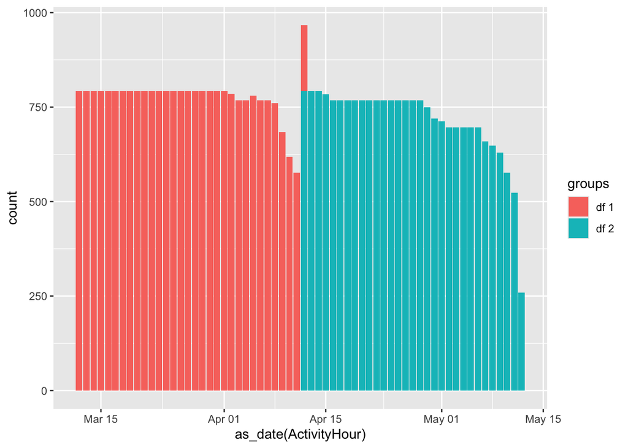

```r
ggplot(bind_rows("df 1" = hourly_calories_03_12, "df 2" = hourly_calories_04_12, .id = "groups"), aes(as_date(ActivityHour), fill = groups)) +
  geom_bar()
```

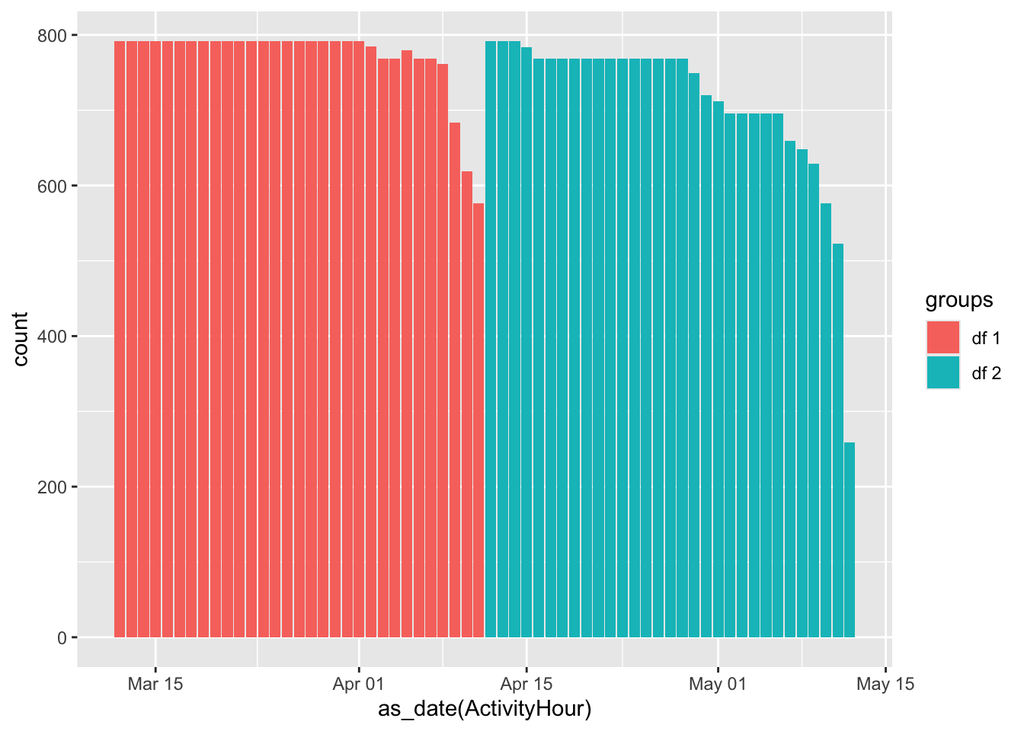

```r
# Using distinct on Id and Activity Hour to drop any duplicates

hourly_calories <- bind_rows("df 1" = hourly_calories_03_12, "df 2" = hourly_calories_04_12, .id = "groups") %>%
  arrange(by = desc(ActivityHour), desc(groups)) %>%
  distinct(Id, ActivityHour, .keep_all = TRUE)

# plotting the data again

ggplot(hourly_calories, aes(as_date(ActivityHour), fill = groups)) +
  geom_bar()
```

Let’s repeat the merging and cleaning steps for other datasets.

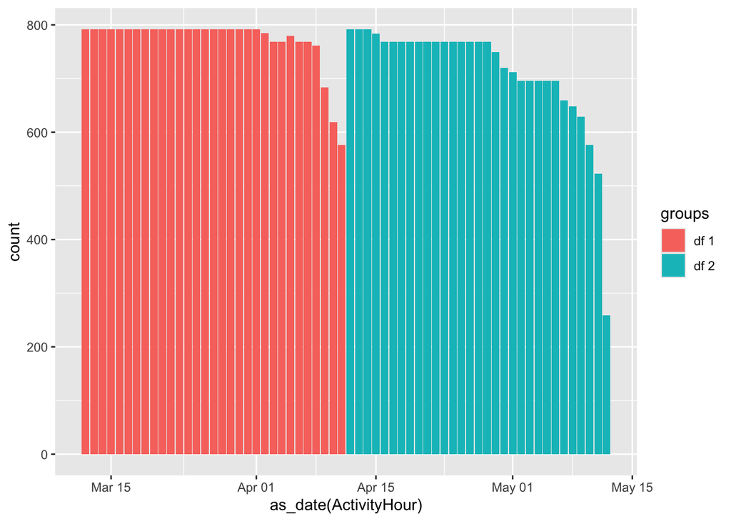

```r
hourly_steps <- bind_rows("df 1" = hourly_steps_03_12, "df 2" = hourly_steps_04_12, .id = "groups") %>%
  arrange(by = desc(ActivityHour), desc(groups)) %>%
  distinct(Id, ActivityHour, .keep_all = TRUE)

ggplot(hourly_steps, aes(as_date(ActivityHour), fill = groups)) +
  geom_bar()
```

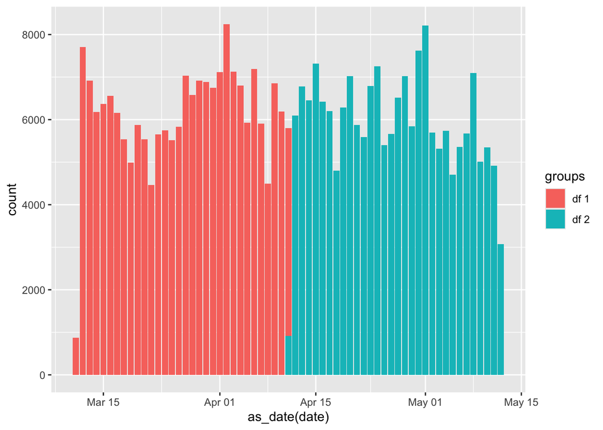

```r
# sleep dataset

minute_sleep <- bind_rows("df 1" = minute_sleep_03_12, "df 2" = minute_sleep_04_12, .id = "groups") %>%
  arrange(by = desc(date), desc(groups)) %>%
  distinct(Id, date, .keep_all = TRUE)

ggplot(minute_sleep, aes(as_date(date), fill = groups)) +
  geom_bar()
```

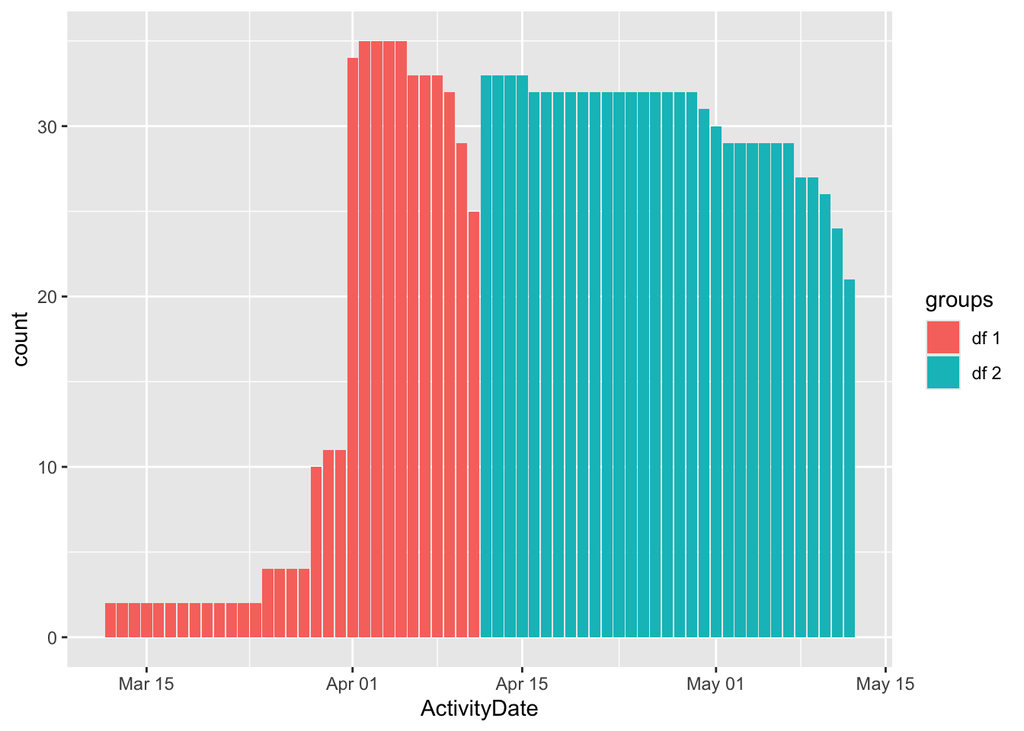

```r
# activity dataset

daily_activity <- bind_rows("df 1" = daily_activity_03_12, "df 2" = daily_activity_04_12, .id = "groups") %>%
  arrange(by = desc(ActivityDate), desc(groups)) %>%
  distinct(Id, ActivityDate, .keep_all = TRUE)

ggplot(daily_activity) +
  geom_bar(mapping = aes(ActivityDate, fill = groups))
```

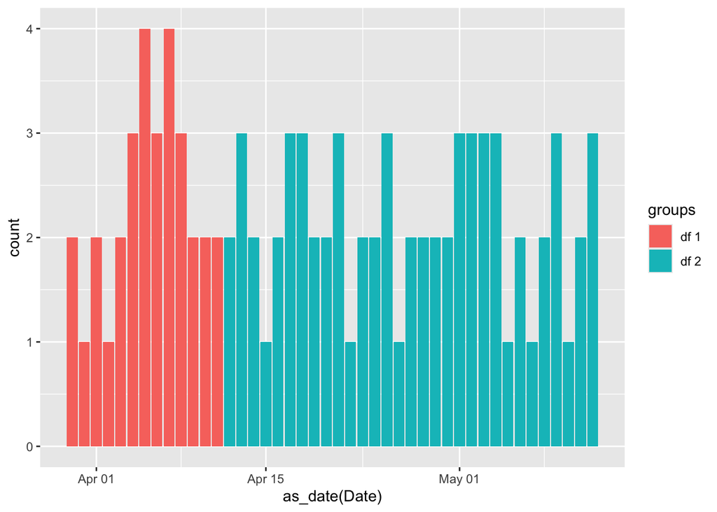

```r
# weight log

weight_log <- bind_rows("df 1" = weight_log_03_12, "df 2" = weight_log_04_12, .id = "groups") %>%
  arrange(by = desc(Date), desc(groups)) %>%
  distinct(Id, Date, .keep_all = TRUE)

ggplot(weight_log) +
  geom_bar(mapping = aes(as_date(Date), fill = groups))
```

```r
# Remove previous datasets

rm(daily_activity_03_12, daily_activity_04_12,
   hourly_calories_03_12, hourly_calories_04_12,
   hourly_steps_03_12, hourly_steps_04_12,
   minute_sleep_03_12, minute_sleep_04_12,
   weight_log_03_12, weight_log_04_12)
```

To ensure consistency across datasets, hourly and minute level datasets will be aggregated into daily summaries. This transformation consolidates data into uniform format, making it easier to compare and analyze trends.

```r
daily_calories <- hourly_calories %>%
  mutate(ActivityDate = as_date(ActivityHour)) %>%
  group_by(Id, ActivityDate) %>%
  summarise(Calories = sum(Calories)) %>%
  arrange(Id, ActivityDate)
```

[output not shown]

```r
daily_steps <- hourly_steps %>%
  mutate(ActivityDate = as_date(ActivityHour)) %>%
  group_by(Id, ActivityDate) %>%
  summarise(StepTotal = sum(StepTotal)) %>%
  arrange(Id, ActivityDate)
```

[output not shown]

```r
daily_sleep <- minute_sleep %>%
  mutate(date = as_date(date)) %>%
  group_by(Id, date) %>%
  summarise(TotalSleepRecords = n_distinct(logId),
            TotalMinutesAsleep = sum(value == 1),
            TotalTimeInBed = n(),
            .groups = "drop") %>%
  arrange(Id, date)

# Remove hourly and minute level datasets

rm(hourly_calories, hourly_steps,
   minute_sleep)
```

Finally, let’s the merge the datasets into a single single source of truth for further exploration and analysis.

```r
daily_activity <- daily_activity %>%
  select(-Calories, -TotalSteps, -groups) %>%
  full_join(daily_calories, join_by("Id" == "Id", "ActivityDate" == "ActivityDate")) %>%
  full_join(daily_steps, join_by("Id" == "Id", "ActivityDate" == "ActivityDate")) %>%
  clean_names()

weight_log <- weight_log %>%
  select(-groups)

rm(daily_calories, daily_steps)
```

Let’s finish this step by performing some data validation techniques to ensure the final dataframe has no duplicates and ready for analysis and clean up the environment by dropping other dataframes.

```r
# Check for duplicates

sum(duplicated(daily_activity))
```

```
## [1] 0
```

```r
sum(duplicated(daily_sleep))
```

```
## [1] 0
```

```r
sum(duplicated(weight_log))
```

```
## [1] 0
```

```r
# Clean column names

daily_activity <- clean_names(daily_activity)
daily_sleep <- clean_names(daily_sleep)
weight_log <- clean_names(weight_log)
```

## 4. Analyze

*Deliverable: A summary of your analysis*

Let’s start with a summary statistics of all columns in our final datasets.

```r
skim_without_charts(daily_activity)
```

Data summary

| Name | daily_activity |
| --- | --- |
| Number of rows | 1966 |
| Number of columns | 15 |
| _______________________ |  |
| Column type frequency: |  |
| character | 1 |
| Date | 1 |
| numeric | 13 |
| ________________________ |  |
| Group variables | None |

**Variable type: character**

| skim_variable | n_missing | complete_rate | min | max | empty | n_unique | whitespace |
| --- | --- | --- | --- | --- | --- | --- | --- |
| id | 0 | 1 | 10 | 10 | 0 | 35 | 0 |

**Variable type: Date**

| skim_variable | n_missing | complete_rate | min | max | median | n_unique |
| --- | --- | --- | --- | --- | --- | --- |
| activity_date | 0 | 1 | 2016-03-12 | 2016-05-12 | 2016-04-10 | 62 |

**Variable type: numeric**

| skim_variable | n_missing | complete_rate | mean | sd | p0 | p25 | p50 | p75 | p100 |
| --- | --- | --- | --- | --- | --- | --- | --- | --- | --- |
| total_distance | 593 | 0.70 | 5.29 | 3.99 | 0 | 2.28 | 5.03 | 7.57 | 28.03 |
| tracker_distance | 593 | 0.70 | 5.26 | 3.97 | 0 | 2.27 | 5.02 | 7.57 | 28.03 |
| logged_activities_distance | 593 | 0.70 | 0.13 | 0.70 | 0 | 0.00 | 0.00 | 0.00 | 6.73 |
| very_active_distance | 593 | 0.70 | 1.41 | 2.62 | 0 | 0.00 | 0.12 | 1.86 | 21.92 |
| moderately_active_distance | 593 | 0.70 | 0.55 | 0.87 | 0 | 0.00 | 0.20 | 0.78 | 6.48 |
| light_active_distance | 593 | 0.70 | 3.24 | 2.10 | 0 | 1.73 | 3.28 | 4.71 | 12.51 |
| sedentary_active_distance | 593 | 0.70 | 0.00 | 0.01 | 0 | 0.00 | 0.00 | 0.00 | 0.11 |
| very_active_minutes | 593 | 0.70 | 19.87 | 31.82 | 0 | 0.00 | 2.00 | 30.00 | 210.00 |
| fairly_active_minutes | 593 | 0.70 | 13.60 | 26.58 | 0 | 0.00 | 6.00 | 18.00 | 660.00 |
| lightly_active_minutes | 593 | 0.70 | 188.10 | 113.10 | 0 | 117.00 | 196.00 | 263.00 | 720.00 |
| sedentary_minutes | 593 | 0.70 | 1001.35 | 304.17 | 0 | 734.00 | 1062.00 | 1246.00 | 1440.00 |
| calories | 31 | 0.98 | 2278.19 | 704.40 | 65 | 1803.00 | 2122.00 | 2747.00 | 4776.00 |
| step_total | 31 | 0.98 | 7201.30 | 5379.68 | 0 | 2912.50 | 6835.00 | 10628.50 | 37322.00 |

```r
skim_without_charts(daily_sleep)
```

Data summary

| Name | daily_sleep |
| --- | --- |
| Number of rows | 901 |
| Number of columns | 5 |
| _______________________ |  |
| Column type frequency: |  |
| character | 1 |
| Date | 1 |
| numeric | 3 |
| ________________________ |  |
| Group variables | None |

**Variable type: character**

| skim_variable | n_missing | complete_rate | min | max | empty | n_unique | whitespace |
| --- | --- | --- | --- | --- | --- | --- | --- |
| id | 0 | 1 | 10 | 10 | 0 | 25 | 0 |

**Variable type: Date**

| skim_variable | n_missing | complete_rate | min | max | median | n_unique |
| --- | --- | --- | --- | --- | --- | --- |
| date | 0 | 1 | 2016-03-11 | 2016-05-12 | 2016-04-11 | 63 |

**Variable type: numeric**

| skim_variable | n_missing | complete_rate | mean | sd | p0 | p25 | p50 | p75 | p100 |
| --- | --- | --- | --- | --- | --- | --- | --- | --- | --- |
| total_sleep_records | 0 | 1 | 1.69 | 0.69 | 1 | 1 | 2 | 2 | 6 |
| total_minutes_asleep | 0 | 1 | 390.59 | 148.89 | 0 | 331 | 416 | 486 | 791 |
| total_time_in_bed | 0 | 1 | 424.84 | 157.34 | 4 | 372 | 449 | 517 | 1038 |

```r
skim_without_charts(weight_log)
```

Data summary

| Name | weight_log |
| --- | --- |
| Number of rows | 98 |
| Number of columns | 8 |
| _______________________ |  |
| Column type frequency: |  |
| character | 1 |
| logical | 1 |
| numeric | 5 |
| POSIXct | 1 |
| ________________________ |  |
| Group variables | None |

**Variable type: character**

| skim_variable | n_missing | complete_rate | min | max | empty | n_unique | whitespace |
| --- | --- | --- | --- | --- | --- | --- | --- |
| id | 0 | 1 | 10 | 10 | 0 | 13 | 0 |

**Variable type: logical**

| skim_variable | n_missing | complete_rate | mean | count |
| --- | --- | --- | --- | --- |
| is_manual_report | 0 | 1 | 0.64 | TRU: 63, FAL: 35 |

**Variable type: numeric**

| skim_variable | n_missing | complete_rate | mean | sd | p0 | p25 | p50 | p75 | p100 |
| --- | --- | --- | --- | --- | --- | --- | --- | --- | --- |
| weight_kg | 0 | 1.00 | 72.47 | 14.82 | 52.60 | 61.50 | 62.50 | 85.25 | 133.50 |
| weight_pounds | 0 | 1.00 | 159.76 | 32.67 | 115.96 | 135.58 | 137.79 | 187.94 | 294.32 |
| fat | 94 | 0.04 | 19.75 | 6.65 | 10.00 | 19.00 | 22.00 | 22.75 | 25.00 |
| bmi | 0 | 1.00 | 25.37 | 3.56 | 21.45 | 24.00 | 24.39 | 25.59 | 47.54 |
| log_id | 0 | 1.00 | 1461187811663.27 | 1089461213.58 | 1459382399000.00 | 1460167292250.00 | 1461122546500.00 | 1462147199000.00 | 1463097599000.00 |

**Variable type: POSIXct**

| skim_variable | n_missing | complete_rate | min | max | median | n_unique |
| --- | --- | --- | --- | --- | --- | --- |
| date | 0 | 1 | 2016-03-30 23:59:59 | 2016-05-12 23:59:59 | 2016-04-20 03:22:26 | 78 |

The study lasted over 62 days with 35 participants and as we can see that there’s fair amount of null values for each variable, we can assume that the participants didn’t use the device everyday. Let’s extract insights on the daily device usage of the participants.

```r
# Calculating avg number of days participants used for tracking activities

# daily activity
daily_activity %>%
  group_by(id) %>%
  summarise(activity_records = n()) %>%
  summary()
```

```
##       id            activity_records
##  Length:35          Min.   : 8.00
##  Class :character   1st Qu.:57.50
##  Mode  :character   Median :62.00
##                     Mean   :56.17
##                     3rd Qu.:62.00
##                     Max.   :62.00
```

```r
# daily sleep

daily_sleep %>%
  group_by(id) %>%
  summarise(activity_records = n()) %>%
  summary()
```

```
##       id            activity_records
##  Length:25          Min.   : 1.00
##  Class :character   1st Qu.:12.00
##  Mode  :character   Median :44.00
##                     Mean   :36.04
##                     3rd Qu.:57.00
##                     Max.   :63.00
```

```r
# weight log

weight_log %>%
  group_by(id) %>%
  summarise(num_of_records = n()) %>%
  summary()
```

```
##       id            num_of_records
##  Length:13          Min.   : 1.000
##  Class :character   1st Qu.: 1.000
##  Mode  :character   Median : 2.000
##                     Mean   : 7.538
##                     3rd Qu.: 4.000
##                     Max.   :43.000
```

Let’s compare the type of activities users spend their time in a day.

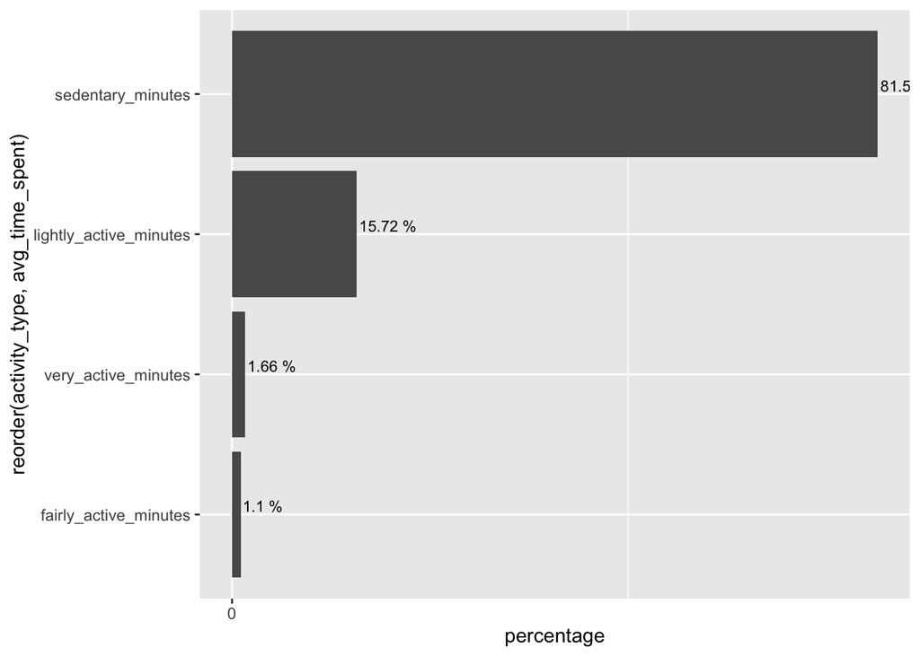

```r
ggplot(daily_activity %>%
         pivot_longer(cols = c(very_active_minutes, fairly_active_minutes, lightly_active_minutes, sedentary_minutes),
                      names_to = "activity_type",
                      values_to = "minutes") %>%
         drop_na() %>%
         group_by(activity_type) %>%
         summarise(avg_time_spent = mean(minutes)) %>%
         mutate(percentage = avg_time_spent / sum(avg_time_spent)*100),
       aes(x = percentage, y = reorder(activity_type, avg_time_spent))) +
  geom_bar(stat = "identity") +
  geom_text(aes(label = paste(round(percentage, 2), "%", sep = " ")), hjust = -0.05, vjust = -0.25, size = 3) +
  scale_x_continuous(breaks = seq(0, 800, 100))
```

On average participants spend over 80% of their time being sedentary with minimal time in very active or fairly active zones..

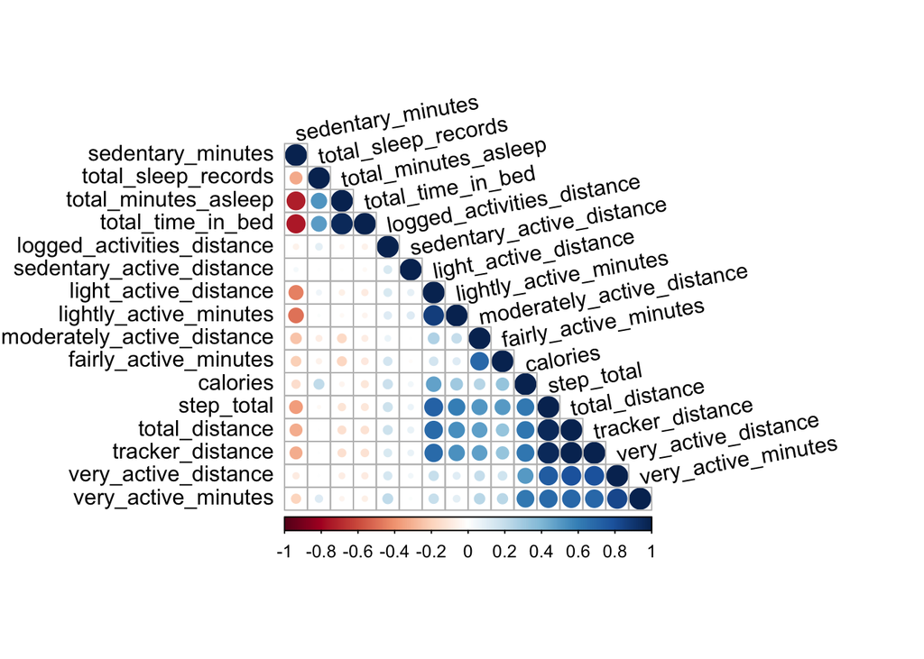

```r
merged_data <- daily_activity %>%
         full_join(daily_sleep, join_by("id" == "id", "activity_date" == "date"))

numeric_df <- merged_data %>%
  select(where(is.numeric))

cor_matrix <- cor(numeric_df, use = "pairwise.complete.obs")

corrplot(cor_matrix, order = "hclust",
         type = "lower",
         tl.col = "black",
         tl.srt = 10)
```

- Calories vs Steps/Distance: Strong positive correlation - Step total & total distance are primary predictors of caloric expenditure - Sedentary Minutes vs Sleep: Strong negative correlation - More sedentary time associated with shorter sleep duration

Finally, let’s look at weekly usage trends.

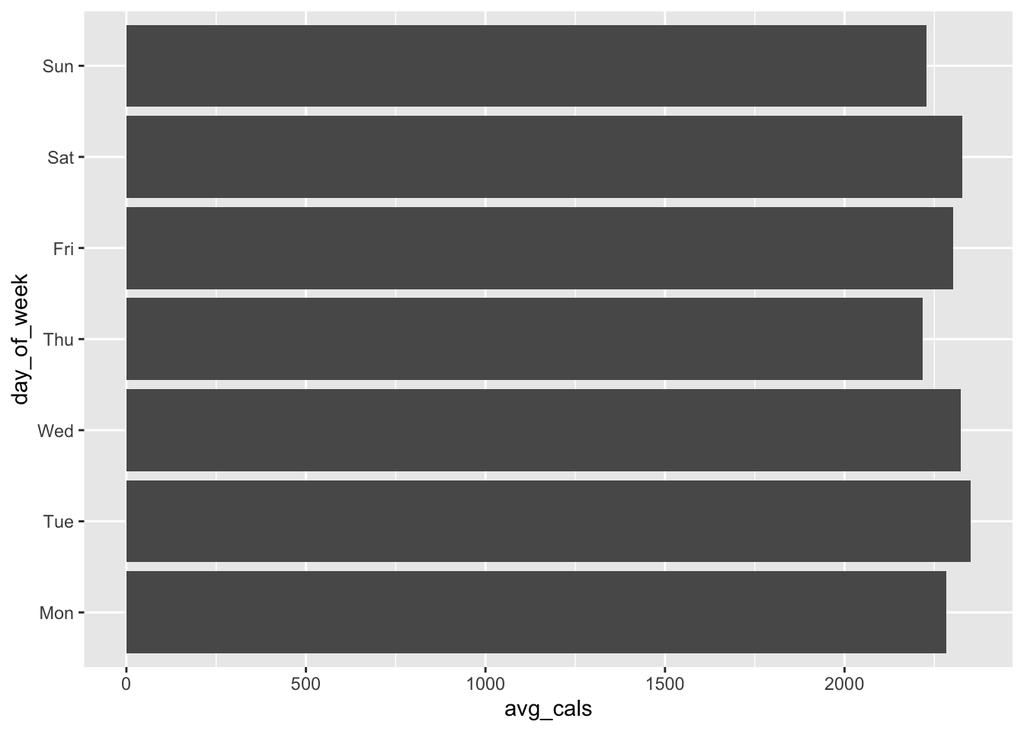

```r
ggplot(daily_activity %>%
         mutate(day_of_week = wday(activity_date, label = TRUE, week_start = 1)) %>%
         drop_na() %>%
         group_by(day_of_week) %>%
         summarise(avg_cals = mean(calories)), aes(x = avg_cals, y = day_of_week)) +
  geom_bar(stat = "identity")
```

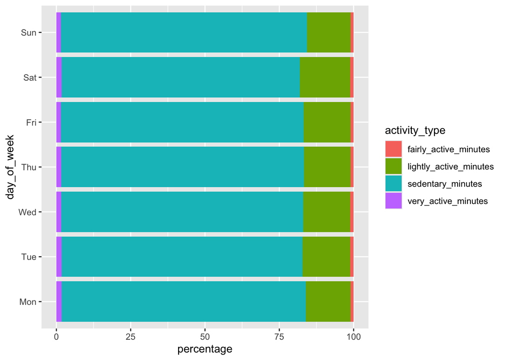

```r
ggplot(daily_activity %>%
         mutate(day_of_week = wday(activity_date, label = TRUE, week_start = 1)) %>%
         pivot_longer(cols = c(very_active_minutes, fairly_active_minutes, lightly_active_minutes, sedentary_minutes),
                      names_to = "activity_type",
                      values_to = "minutes") %>%
         drop_na() %>%
         group_by(day_of_week, activity_type) %>%
         summarise(avg_time_spent = mean(minutes)) %>%
         mutate(percentage = avg_time_spent / sum(avg_time_spent)*100), aes(x = percentage, y = day_of_week, fill = activity_type)) +
  geom_bar(stat = "identity")
```

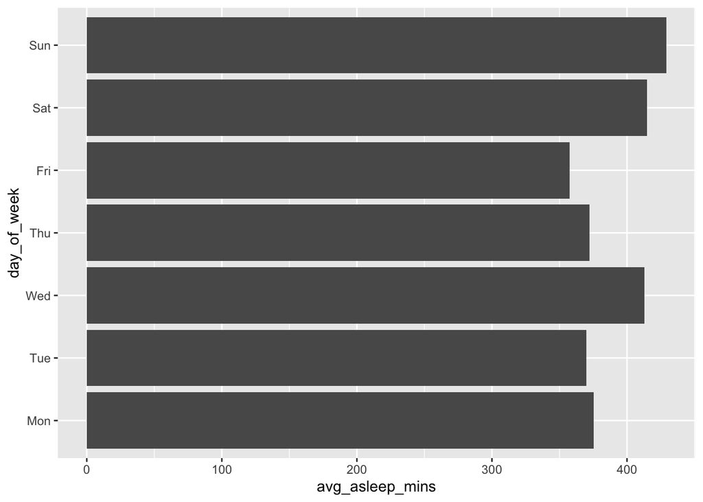

```r
ggplot(daily_sleep %>%
         mutate(day_of_week = wday(date, label = TRUE, week_start = 1)) %>%
         drop_na() %>%
         group_by(day_of_week) %>%
         summarise(avg_asleep_mins = mean(total_minutes_asleep)), aes(x = avg_asleep_mins, y = day_of_week)) +
  geom_bar(stat = "identity")
```

## 5. Share

*Deliverable: Your top high-level insights based on your analysis*